# EDA2

```r
library(tidyverse)
library(leaflet)
```

Load dataset

```r
countries_aggregated <- read_csv("dataset/data/countries-aggregated.csv")
key_countries_pivoted <- read_csv("dataset/data/key-countries-pivoted.csv")
reference <- read_csv("dataset/data/reference.csv")
time_series_19_covid_combined <- read_csv("dataset/data/time-series-19-covid-combined.csv")
us_confirmed <- read_csv("dataset/data/us_confirmed.csv")
us_deaths <- read_csv("dataset/data/us_deaths.csv")
worldwide_aggregated <- read_csv("dataset/data/worldwide-aggregated.csv")
```

Earliest Cases

```r
time_series_19_covid_combined %>%
  select(Date, `Country/Region`, `Province/State`, Confirmed, Recovered, Deaths) %>%
  filter(Date == min(Date) & Confirmed > 0) %>%
  arrange(`Country/Region`)
```

```
## # A tibble: 29 x 6
##    Date       `Country/Region` `Province/State` Confirmed Recovered Deaths
##    <date>     <chr>            <chr>                <dbl>     <dbl>  <dbl>
##  1 2020-01-22 China            Anhui                    1         0      0
##  2 2020-01-22 China            Beijing                 14         0      0
##  3 2020-01-22 China            Chongqing                6         0      0
##  4 2020-01-22 China            Fujian                   1         0      0
##  5 2020-01-22 China            Guangdong               26         0      0
##  6 2020-01-22 China            Guangxi                  2         0      0
##  7 2020-01-22 China            Guizhou                  1         0      0
##  8 2020-01-22 China            Hainan                   4         0      0
##  9 2020-01-22 China            Hebei                    1         0      0
## 10 2020-01-22 China            Henan                    5         0      0
## # … with 19 more rows
```

Latest Cases

```r
time_series_19_covid_combined %>%
  select(Date, `Country/Region`, `Province/State`, Confirmed, Recovered, Deaths) %>%
  filter(Date == max(Date) & Confirmed > 0) %>%
  arrange(`Country/Region`)
```

```
## # A tibble: 265 x 6
##    Date       `Country/Region`   `Province/State`     Confirmed Recovered Deaths
##    <date>     <chr>              <chr>                    <dbl>     <dbl>  <dbl>
##  1 2020-05-04 Afghanistan        <NA>                      2894       397     90
##  2 2020-05-04 Albania            <NA>                       803       543     31
##  3 2020-05-04 Algeria            <NA>                      4648      1998    465
##  4 2020-05-04 Andorra            <NA>                       750       499     45
##  5 2020-05-04 Angola             <NA>                        35        11      2
##  6 2020-05-04 Antigua and Barbu… <NA>                        25        15      3
##  7 2020-05-04 Argentina          <NA>                      4887      1442    260
##  8 2020-05-04 Armenia            <NA>                      2507      1071     39
##  9 2020-05-04 Australia          Australian Capital …       107       103      3
## 10 2020-05-04 Australia          New South Wales           3035      2349     43
## # … with 255 more rows
```

Summary Plot of Worldwide Cases - Confirmed, Deaths & Recovered

[figure not shown]

```r
countries_aggregated %>%
  filter(Date == max(Date) & Confirmed > 0) %>%
  select(Country, Confirmed, Recovered, Deaths) %>%
  gather(key, value, -Country) %>%
  ggplot(aes(`Country`, value, fill=key)) + geom_bar(stat="identity", position="dodge")
```

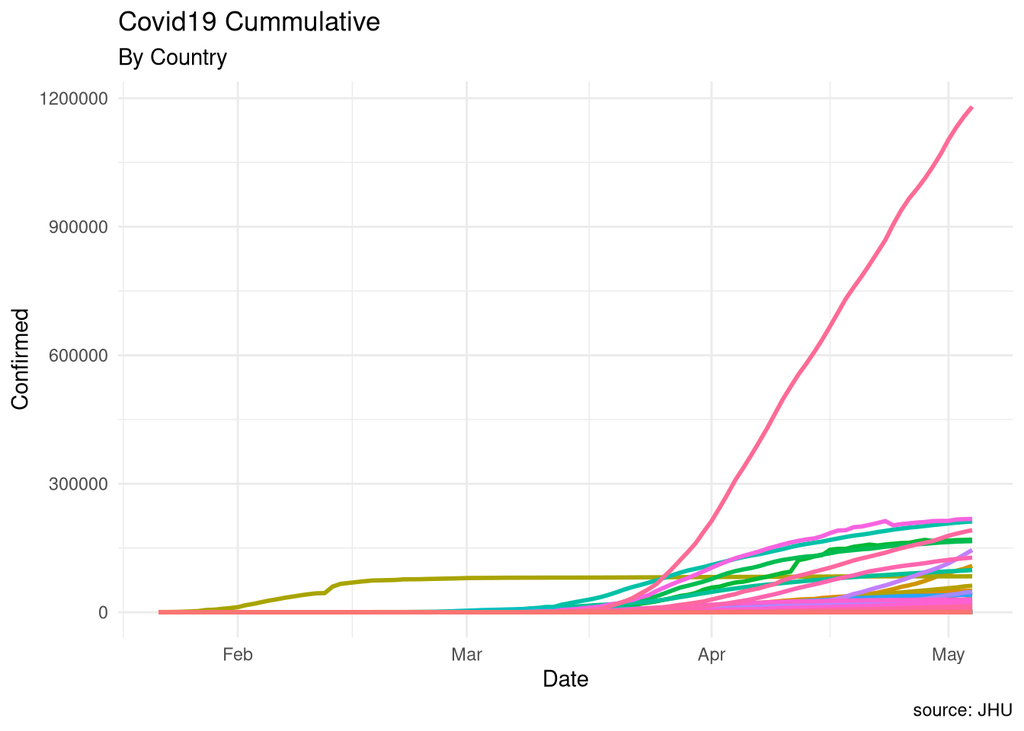

```r
ggplot(countries_aggregated,
       aes(x=Date, y=Confirmed, color=`Country`)) +
  geom_line(size=1) +
  scale_x_date(date_breaks = '1 month',
               labels = scales::date_format("%b")) +
  scale_y_continuous() +
  labs(title = "Covid19 Cummulative",
       subtitle = "By Country",
       caption = "source: JHU",
       y = "Confirmed") +
  theme_minimal() +
  theme(legend.position = "none")
```

Countries/Regions Affected

```r
unique(countries_aggregated$Country)
```

```
##   [1] "Afghanistan"                      "Albania"
##   [3] "Algeria"                          "Andorra"
##   [5] "Angola"                           "Antigua and Barbuda"
##   [7] "Argentina"                        "Armenia"
##   [9] "Australia"                        "Austria"
##  [11] "Azerbaijan"                       "Bahamas"
##  [13] "Bahrain"                          "Bangladesh"
##  [15] "Barbados"                         "Belarus"
##  [17] "Belgium"                          "Belize"
##  [19] "Benin"                            "Bhutan"
##  [21] "Bolivia"                          "Bosnia and Herzegovina"
##  [23] "Botswana"                         "Brazil"
##  [25] "Brunei"                           "Bulgaria"
##  [27] "Burkina Faso"                     "Burma"
##  [29] "Burundi"                          "Cabo Verde"
```

[output cut: 79 more lines]

Countries/Regions Affected (Map)

```r
pal <- colorFactor(c("navy", "red", "green"), domain = c("Confirmed", "Deaths", "Recovered"))

time_series_19_covid_combined %>%
  filter(Date == last(Date)) %>%
  group_by(`Country/Region`) %>%
  summarize(Lat=first(na.omit(Lat)), Long=first(na.omit(Long)), Confirmed=sum(Confirmed), Recovered=sum(Recovered), Deaths=sum(Deaths)) %>%
  leaflet() %>%
  addTiles() %>%
  addCircleMarkers(
    stroke = FALSE,
    fillOpacity = 0.3,
    radius = ~Confirmed/10000,
    color = ~pal('Confirmed')
  ) %>%
  addCircleMarkers(
    stroke = FALSE,
    fillOpacity = 0.4,
    radius = ~Recovered/10000,
    color = ~pal('Recovered')
  ) %>%
  addCircleMarkers(
    stroke = FALSE,
    fillOpacity = 0.6,
    radius = ~Deaths/10000,
    color = ~pal('Deaths')
  )
```

```
## Assuming "Long" and "Lat" are longitude and latitude, respectively
## Assuming "Long" and "Lat" are longitude and latitude, respectively
## Assuming "Long" and "Lat" are longitude and latitude, respectively
```

[interactive chart not shown]

Forecasting Total Number of Cases Worldwide

Prophet We use Prophet, a procedure for forecasting time series data based on an additive model where non-linear trends are fit with yearly, weekly, and daily seasonality, plus holiday effects. It works best with time series that have strong seasonal effects and several seasons of historical data. Prophet is robust to missing data and shifts in the trend, and typically handles outliers well. It is also an open source software released by Facebook’s Core Data Science team. It is available for download on CRAN and PyPI.

Why Prophet? Prophet is easy to customize and use, and to produce accurate forecasts which can be explained intuitively with supporting evidence such as forecast seasonality components. It allows the analyst to explain in an intuitive and convinving manner to higher management as to why the forecasts are as such, and the plausible underlying factors that contribute to its result. Furthermore, it is also open-source! :)

```r
library(prophet)
```

Predict Confirmed Trend

```r
m <- worldwide_aggregated %>%
  rename(ds=Date, y=Confirmed) %>%
  prophet()
```

```
## Disabling yearly seasonality. Run prophet with yearly.seasonality=TRUE to override this.
```

```
## Disabling daily seasonality. Run prophet with daily.seasonality=TRUE to override this.
```

```r
m
```

[output not shown]

[output cut: 184 more lines]

[output not shown]

Predictions are made on a dataframe with a column ds containing the dates for which predictions are to be made. The make_future_dataframe function takes the model object and a number of periods to forecast and produces a suitable dataframe. By default it will also include the historical dates so we can evaluate in-sample fit.

```r
future <- make_future_dataframe(m, periods = 365)
tail(future)
```

```
##             ds
## 464 2021-04-29
## 465 2021-04-30
## 466 2021-05-01
## 467 2021-05-02
## 468 2021-05-03
## 469 2021-05-04
```

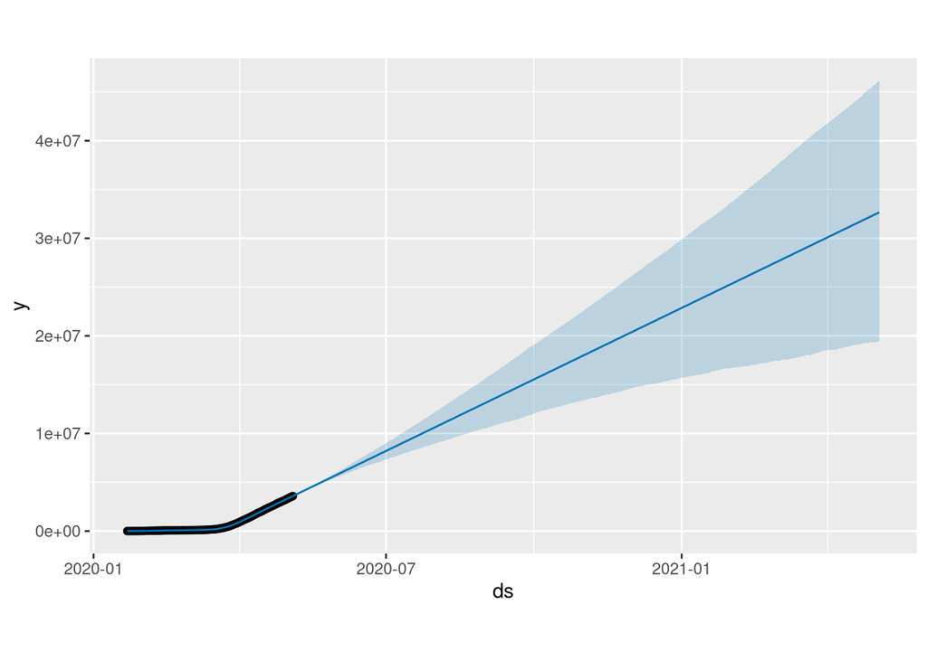

```r
forecast <- predict(m, future)
plot(m, forecast)
```

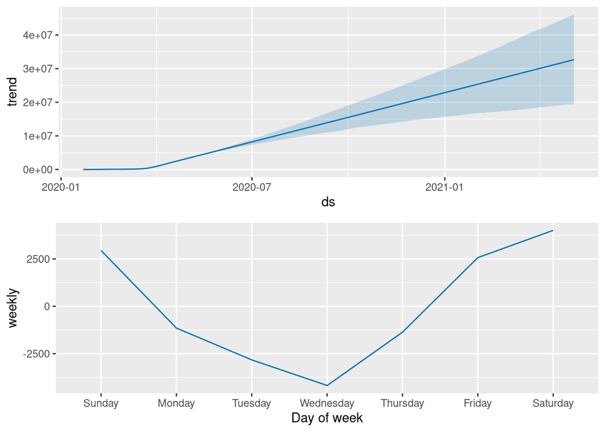

```r
prophet_plot_components(m, forecast)
```

Predict Deaths Trend

```r
m2 <- worldwide_aggregated %>%
  rename(ds=Date, y=Deaths) %>%
  prophet()
```

```
## Disabling yearly seasonality. Run prophet with yearly.seasonality=TRUE to override this.
```

```
## Disabling daily seasonality. Run prophet with daily.seasonality=TRUE to override this.
```

```r
future2 <- make_future_dataframe(m2, periods = 365)
tail(future2)
```

```
##             ds
## 464 2021-04-29
## 465 2021-04-30
## 466 2021-05-01
## 467 2021-05-02
## 468 2021-05-03
## 469 2021-05-04
```

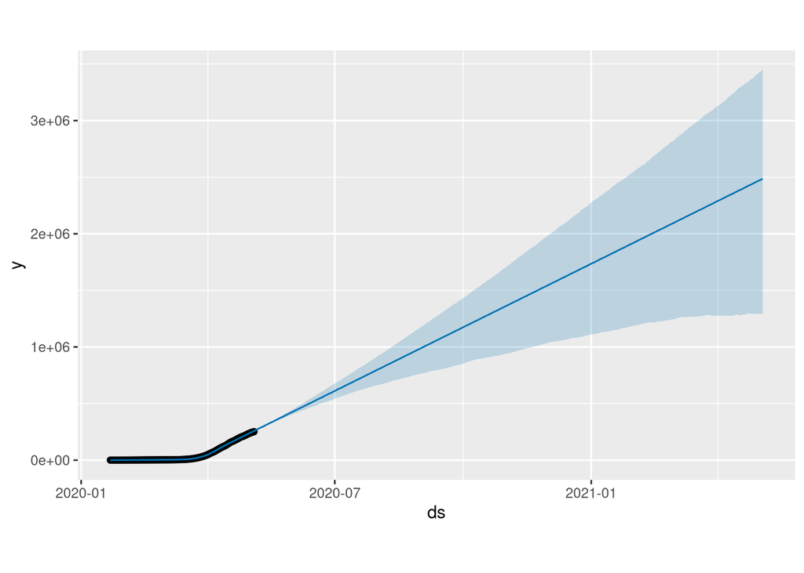

```r
forecast2 <- predict(m2, future2)
plot(m2, forecast2)
```

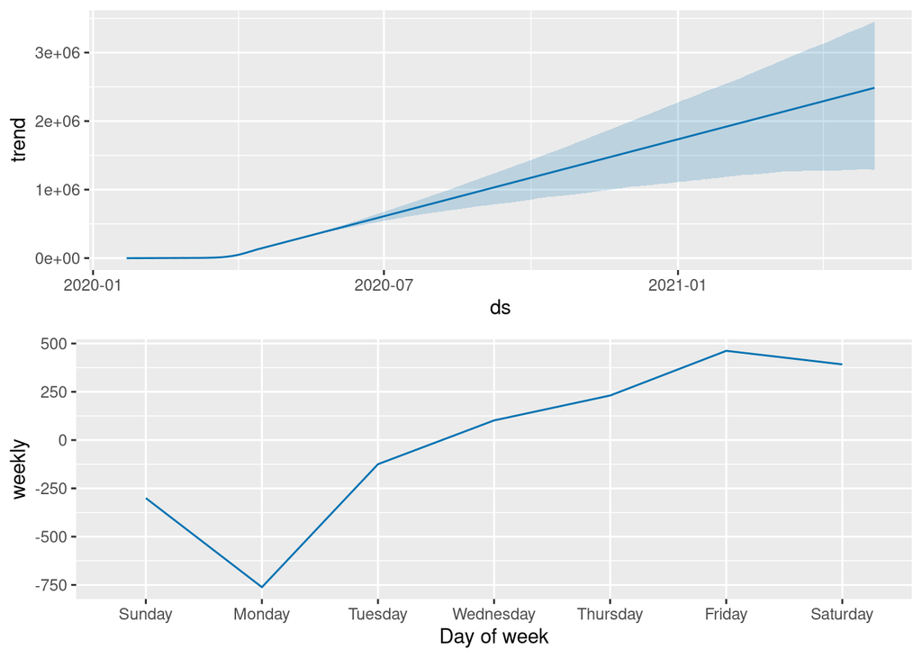

```r
prophet_plot_components(m2, forecast2)
```

Predict Recovered Trend

```r
m2 <- worldwide_aggregated %>%
  rename(ds=Date, y=Recovered) %>%
  prophet()
```

```
## Disabling yearly seasonality. Run prophet with yearly.seasonality=TRUE to override this.
```

```
## Disabling daily seasonality. Run prophet with daily.seasonality=TRUE to override this.
```

```r
future2 <- make_future_dataframe(m2, periods = 365)
tail(future2)
```

```
##             ds
## 464 2021-04-29
## 465 2021-04-30
## 466 2021-05-01
## 467 2021-05-02
## 468 2021-05-03
## 469 2021-05-04
```

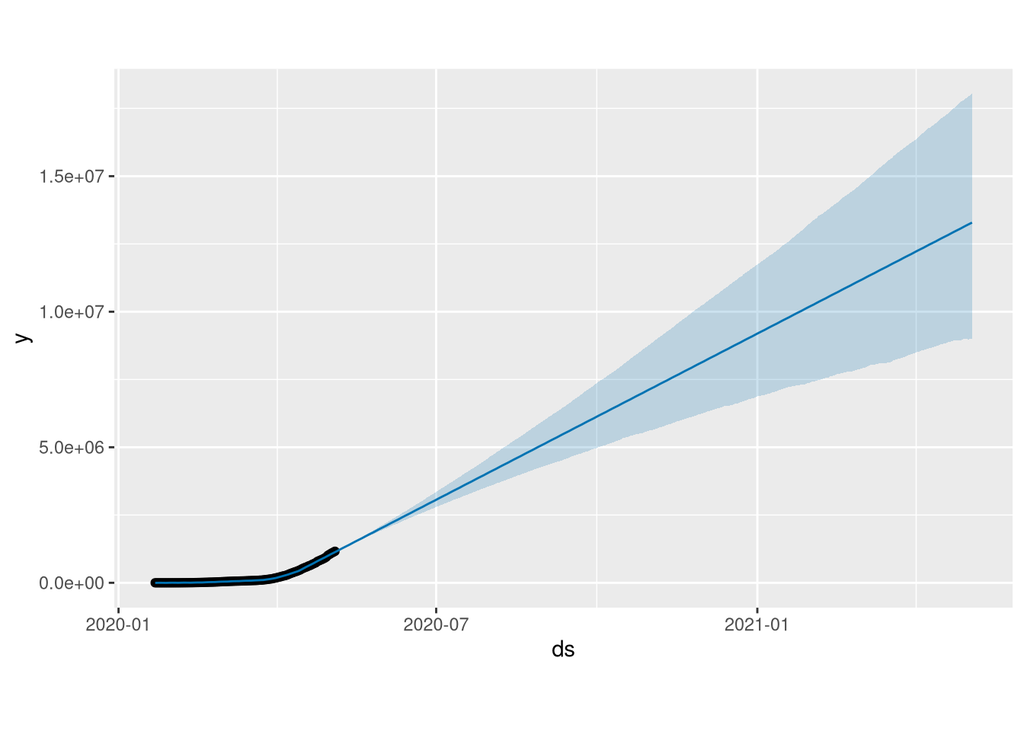

```r
forecast2 <- predict(m2, future2)
plot(m2, forecast2)
```

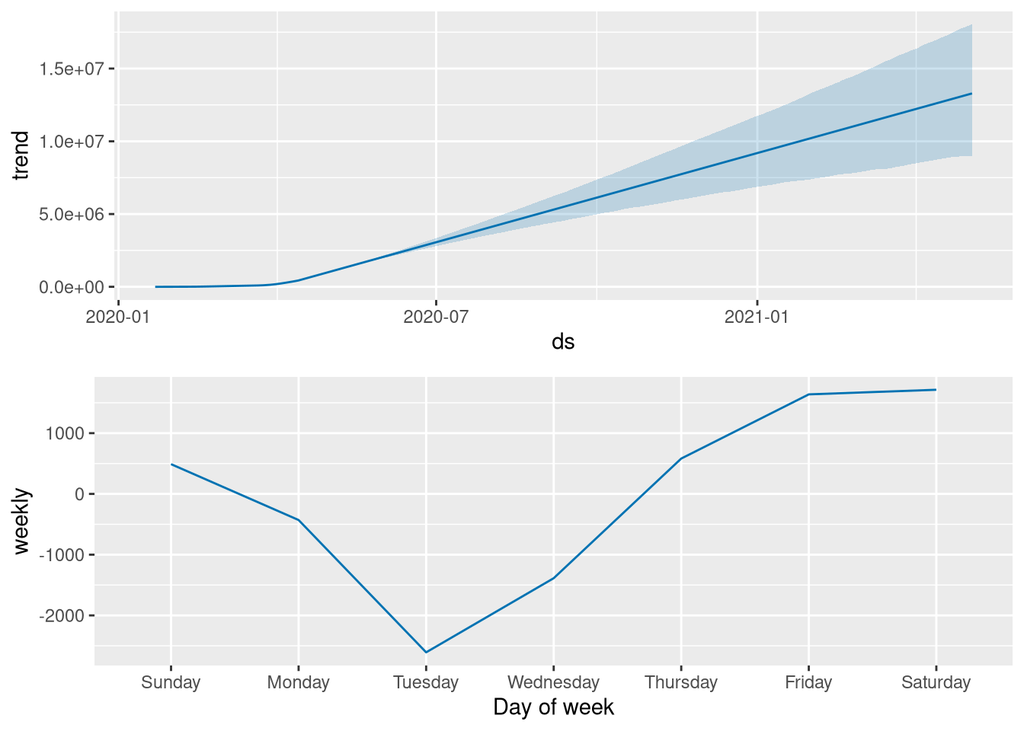

```r
prophet_plot_components(m2, forecast2)
```